# CFRM 502, Winter 2020

# Instructor: Bahman Angoshtari

# Lecture 5

**Chapter 11:** Parametric non-linear regressions, transform-both-sides (TBS), Box-Cox transformation, logit regression, least-trimmed sum of squares (LTS) regression

$\newcommand{\eps}{\varepsilon}$ $\newcommand{\Var}{\operatorname{Var}}$ $\newcommand\Cov{\operatorname{Cov}}$ $\newcommand{\sig}{\sigma}$ $\newcommand{\al}{\alpha}$ $\newcommand{\Xb}{\bar{X}}$ $\newcommand{\Yb}{\bar{Y}}$ $\newcommand\Eb{\mathbb{E}}$ $\newcommand\Pb{\mathbb{P}}$ $\newcommand\Qb{\mathbb{Q}}$ $\newcommand\Rb{\mathbb{R}}$ $\newcommand\Zb{\mathbb{Z}}$ $\newcommand\Nb{\mathbb{N}}$ $\newcommand\Av{\textbf{A}}$ $\newcommand\Fv{\textbf{F}}$ $\newcommand\Gv{\textbf{G}}$ $\newcommand\Hv{\textbf{H}}$ $\newcommand\Kv{\textbf{K}}$ $\newcommand\Iv{\textbf{I}}$ $\newcommand\Pv{\textbf{P}}$ $\newcommand\Sv{\textbf{S}}$ $\newcommand\Xv{\textbf{X}}$ $\newcommand\Yv{\textbf{Y}}$ $\newcommand\Zv{\textbf{Z}}$ $\newcommand\av{\mathbf{a}}$ $\newcommand\xv{\mathbf{x}}$ $\newcommand\yv{\mathbf{y}}$ $\newcommand\zv{\mathbf{z}}$ $\newcommand\Cv{\mathbf{C}}$ $\newcommand\mv{\mathbf{m}}$ $\newcommand\nv{\mathbf{n}}$ $\newcommand\pv{\mathbf{p}}$ $\newcommand\sv{\mathbf{s}}$ $\newcommand\wv{\mathbf{w}}$ $\newcommand\Wv{\textbf{W}}$ $\newcommand\betav{{\boldsymbol\beta}}$ $\newcommand\etav{{\boldsymbol\eta}}$ $\newcommand\epsv{{\boldsymbol\varepsilon}}$ $\newcommand\delv{{\boldsymbol\delta}}$ $\newcommand\Lamv{{\boldsymbol\Lambda}}$ $\newcommand\lamv{{\boldsymbol\lambda}}$ $\newcommand\muv{{\boldsymbol\mu}}$ $\newcommand\piv{{\boldsymbol\pi}}$ $\newcommand\Pbh{\widehat{\Pb}}$ $\newcommand\Ebh{\widehat{\Eb}}$ $\newcommand\Qh{\widehat{Q}}$ $\newcommand\Ih{\widehat{I}}$ $\newcommand\pih{\widehat{\pi}}$ $\newcommand\Pih{\widehat{\Pi}}$ $\newcommand\Wh{\widehat{W}}$ $\newcommand\Fh{\widehat{F}}$ $\newcommand\Yh{\widehat{Y}}$ $\newcommand\Yvh{\widehat{\Yv}}$ $\newcommand\Ah{\widehat{\Ac}}$ $\newcommand\uh{\widehat{u}}$ $\newcommand\vh{\widehat{v}}$ $\newcommand\fh{\widehat{f}}$ $\newcommand\hh{\widehat{h}}$ $\newcommand\Bh{\widehat{B}}$ $\newcommand\rhoh{\widehat{\rho}}$ $\newcommand\nuh{\widehat{\nu}}$ $\newcommand\varphih{\widehat{\varphi}}$ $\newcommand\alh{\widehat{\al}}$ $\newcommand\thetah{\widehat{\theta}}$ $\newcommand\betah{\widehat{\beta}}$ $\newcommand\betavh{\widehat{\boldsymbol\beta}}$ $\newcommand\kaph{\widehat{\kappa}}$ $\newcommand\sigh{\widehat{\sigma}}$ $\newcommand\epsh{\widehat{\eps}}$ $\newcommand\epsvh{\widehat{\epsv}}$ $\newcommand\epst{\widetilde{\eps}}$ $\newcommand\muh{\widehat{\mu}}$ $\newcommand\dd{\mathrm{d}}$ $\newcommand\ee{\mathrm{e}}$

# 0. Overview of the lecture

- In many applications, linear models do not capture the reality (according to Box's quote, they are not useful) and we have to consider non-linear models
- There are two types of nonlinear regression models
  - **parametric non-linear regression:** the form of the regression equation is a nonlinear, but **prespecified**, function that is parametrized by **finite** number of parameters
  - **non-parametric regression:** the form of the regression equation is **not prespecified**. Instead, one finds the best function in a general function space (say set of continuous functions or smooth functions, etc.) that best "fits" the data according to some criterion
- In this lecture, we see how to fit a parametric non-linear regression (non-parametric regression will be discussed in the next lecture).
- We then discuss three classes of common parametric non-linear regression models
  - TBS and Cox-Box transformation: used for remedying abnormalities such as non-constant variance and non-normality
  - logit (or logistic) regression: used for classification task (predicting types instead of values)
  - Robust regression: regression models that are less sensitive to outliers

# 1. Parametric non-linear regression

- The general parametric regression model:

\begin{align*} Y_n = f(\Xv_n;\betav) + \eps_n;\quad n\in\{1,\dots,N\} \end{align*}

- $\{(Y_n, \Xv_n)\}_{n=1}^N$ is a sample of observations
- $f$ is a known function (called the regression equation or function)
- $\betav=(\beta_1,\dots,\beta_p)$ is a vector of unknown parameters
- $\{\eps_n\}_{n=1}^N$ are white noise (that is, they are i.i.d. with zero mean and finite variance)
- $\betav$ is estimated by non-linear least squares (NLS) estimator:

\begin{align*} \betavh = \underset{\betav}{\arg\min}\,\sum_{n=1}^N \Big(Y_n - f(\Xv_n;\betav)\Big)^2. \end{align*}

- Many statistical softwares (including R) have functions that numerically obtain NLS estimators
- Once $\betav$ is found, the fitted values are $\Yh_n = f(\Xv_n;\betavh)$ and the residuals are $\epsh_n=Y_n-\Yh_n$
- Diagnostic of parametric regression models is similar to diagnostic of linear regression model
- One should check that:
  - There is no systematic pattern in the residuals: plot raw residuals vs. fitted values
  - Residuals are uncorrelated (e.g. ACF plot of the residuals)
  - Residuals have constant conditional variance: use the plot of raw absolute residual vs. fitted values
- It is possible to define externally studentized residuals (rstudent) for nonlinear models. However, in this course, it suffices to use the raw residuals for diagnostics of parametric non-linear models
- As an example, consider the relationship between credit rating of a company $X$ and its probability of default $Y$
- We look at a sample of companies over a period. The credit ratings are labeled as 1 (the best credit rating of AAA) to 16 (the worst credit rating of B3)
- Let $Y_n$ be the percentage of the companies with credit rating $X_n$ that defaulted over a fixed period of time

```r
DefaultData = read.table("DefaultData.txt",header=T)
DefaultData$freq = DefaultData$freq/100 # converting percentages to fractions
DefaultData
```

A data.frame: 16 × 2

| rating <dbl> | freq <dbl> |
| --- | --- |
| 1 | 0.0000 |
| 2 | 0.0000 |
| 3 | 0.0000 |
| 4 | 0.0008 |
| 5 | 0.0000 |
| 6 | 0.0000 |
| 7 | 0.0000 |
| 8 | 0.0006 |
| 9 | 0.0006 |
| 10 | 0.0046 |
| 11 | 0.0069 |
| 12 | 0.0063 |
| 13 | 0.0239 |
| 14 | 0.0379 |
| 15 | 0.0796 |
| 16 | 0.1289 |

```r
# Setting parameters of the Jupyter notebook
sc = .75
options(repr.plot.width=16*sc,
        repr.plot.height=7*sc,
        repr.plot.pointsize = 13, # Text height in pt
        repr.plot.bg        = 'white',
        repr.plot.antialias = 'gray',
        #nice medium-res DPI
        repr.plot.res       = 300,
        #jpeg quality bumped from default
        repr.plot.quality   = 90,
        #vector font family
        repr.plot.family    = 'serif') # Vector font family. 'sans', 'serif', 'mono' or a specific one
```

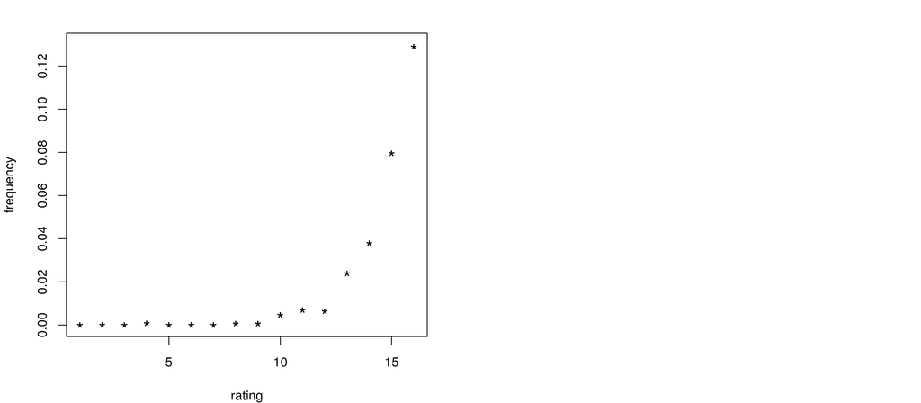

```r
par(mfrow=c(1,2));par(mar=c(4,4,2,2))
plot(DefaultData$rating,DefaultData$freq,
     ylim=c(-.0001,.13),pch="*",ylab="frequency", xlab="rating",cex=1.5)
```

- We propose the following parametric regression models \begin{align*} Y_n = e^{\beta_0 + \beta_1 X_n + \eps_n};\quad \eps_n\overset{i.i.d.}{\sim} N(0,1) \end{align*} and \begin{align*} Y_n = e^{\beta_0 + \beta_1 X_n} + \eps_n;\quad \eps_n\overset{i.i.d.}{\sim} N(0,1) \end{align*}
- Q: Do you see the difference between these two models?
- The first model is a linear multiple regression model "in disguise"
- We can re-write it as follows: define $\tilde{Y}_n=\log Y_n$, such that

\begin{align*} \tilde{Y}_n = \beta_0 + \beta_1 X_n + \eps_n;\quad \eps_n\overset{i.i.d.}{\sim} N(0,1) \end{align*}

- We can use OLS (ordinary least squares) to fit this model
- The second model is truly non-linear. It can be fitted by NLS
- Some nonlinearities are **"removable"**
- For example, polynomial regression mode, $f(x;\betav) = \beta_0 + \beta_1\,x + \dots + \beta_p\,x^p$

  can be transform to a linear multiple regression model. Can you guess how?
- Read section 11.7 of the textbook for further information
- Let us fit the first model, that is

\begin{align*} \log Y_n = \beta_0 + \beta_1 X_n + \eps_n;\quad \eps_n\overset{i.i.d.}{\sim} N(0,1) \end{align*}

- To fit the first model, we need to drop the 0 frequencies (why?)

```r
attach(DefaultData) # this line lets us use the columns names as variables
y = log(freq[freq>0])
x = rating[freq>0]

fit_OLS = lm(y ~ x)
```

- By dropping the observation with zero frequency, we are throwing away data. Not a good practice...

```r
summary(fit_OLS)
```

```
Call:
lm(formula = y ~ x)

Residuals:
    Min      1Q  Median      3Q     Max
-1.4082 -0.4247  0.1661  0.3800  1.4079

Coefficients:
             Estimate Std. Error t value Pr(>|t|)
(Intercept) -10.56144    0.90445 -11.677 2.64e-06 ***
x             0.50567    0.07722   6.549 0.000179 ***
---
Signif. codes:  0 ‘***’ 0.001 ‘**’ 0.01 ‘*’ 0.05 ‘.’ 0.1 ‘ ’ 1

Residual standard error: 0.8374 on 8 degrees of freedom
Multiple R-squared:  0.8428,	Adjusted R-squared:  0.8231
F-statistic: 42.89 on 1 and 8 DF,  p-value: 0.0001787
```

- The following code generate a scatter plot of the sample and the fitted model the fitted model

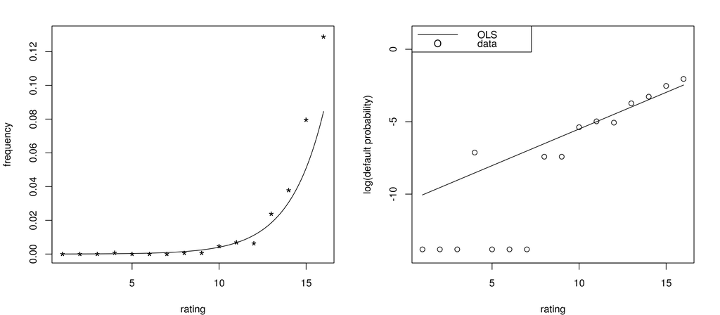

```r
par(mfrow=c(1,2));par(mar=c(4,4,2,2))
rate_grid = seq(1,16,by=.01)
coef_OLS = as.numeric(coef(fit_OLS)); logY_grid_OLS = coef_OLS[1]+coef_OLS[2]*rate_grid
plot(rating,freq,ylim=c(-.0001,.13),pch="*",ylab="frequency",cex=1.5)
lines(rate_grid,exp(logY_grid_OLS))
plot(rate_grid, logY_grid_OLS,
     type="l",ylim=c(-14.15,1),xlab="rating",ylab="log(default probability)")
points(rating,log(freq+1e-6)) # we added 1e-6 so the zero frequencies become visible
legend("topleft",c("OLS","data"),lty=c(1,NA),pch=c("","O"),col=c("black"))
```

- Dropping the zero frequency observations introduces bias in the model, especially for values of rating >13 (these are the companies with lower credit ratings)
- Next, we fit the second model, that is

\begin{align*} Y_n = e^{\beta_0 + \beta_1 X_n} + \eps_n;\quad \eps_n\overset{i.i.d.}{\sim} N(0,1) \end{align*}

- Since we don't transform the response, there is no need to drop the zero frequencies observations!
- To fit the second model, we can use the R function `nls()`.
- It uses an iterative optimization method, so, we need to give it an initial guess for the parameters using the argument `start=`

```r
fit_NLS = nls(freq ~ exp(b1+b2*rating), start=list(b1=-5,b2=.5))
summary(fit_NLS)
```

```
Formula: freq ~ exp(b1 + b2 * rating)

Parameters:
    Estimate Std. Error t value Pr(>|t|)
b1 -11.40672    0.32947  -34.62 5.76e-15 ***
b2   0.58602    0.02116   27.70 1.25e-13 ***
---
Signif. codes:  0 ‘***’ 0.001 ‘**’ 0.01 ‘*’ 0.05 ‘.’ 0.1 ‘ ’ 1

Residual standard error: 0.002695 on 14 degrees of freedom

Number of iterations to convergence: 10
Achieved convergence tolerance: 6.69e-06
```

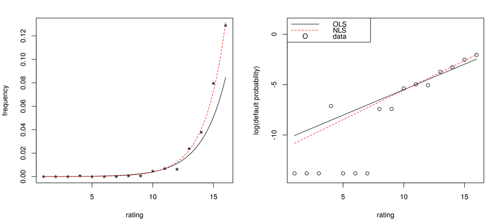

```r
par(mfrow=c(1,2));par(mar=c(4,4,2,2))
coef_NLS = as.numeric(coef(fit_NLS))
logY_grid_NLS = coef_NLS[1]+coef_NLS[2]*rate_grid
plot(rating,freq,ylim=c(-.0001,.13),pch="*",ylab="frequency",cex=1.5)
lines(rate_grid,exp(logY_grid_OLS))
lines(rate_grid,exp(logY_grid_NLS),lty=2,col="red")
plot(rate_grid, logY_grid_OLS,
     type="l",ylim=c(-14.15,1),xlab="rating",ylab="log(default probability)")
lines(rate_grid,logY_grid_NLS,lty=2,col="red")
points(rating,log(freq+1e-6)) # we added 1e-6 so the zero frequencies become visible
legend("topleft",c("OLS","NLS","data"),lty=c(1,2,NA),pch=c("","","O"),col=c("black","red"))
```

- Finally, we conduct a (partial) residual analysis.

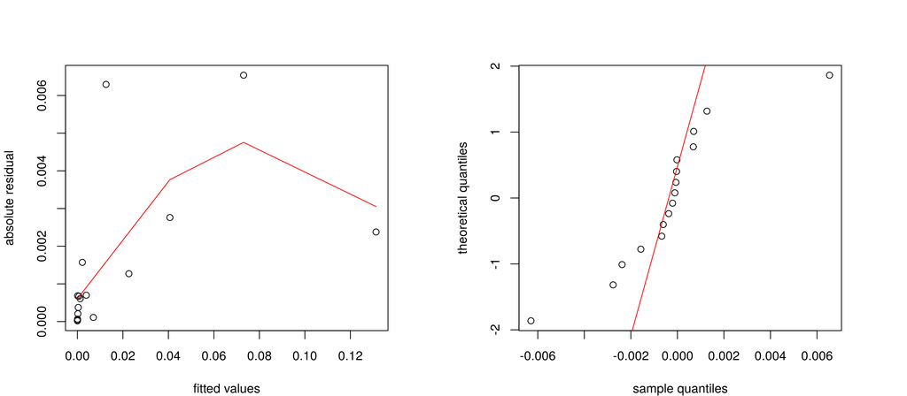

```r
par(mfrow=c(1,2));par(mar=c(4,4,4,4))
plot(fitted(fit_NLS),abs(resid(fit_NLS)),
     xlab="fitted values", ylab="absolute residual")
fit_loess  = loess(abs(resid(fit_NLS))~ fitted(fit_NLS),span=1,deg=1)
ord_NLS = order(fitted(fit_NLS))
lines(fitted(fit_NLS)[ord_NLS],fit_loess$fit[ord_NLS], col="red")
qqnorm(resid(fit_NLS),datax=T,main="",ylab="sample quantiles",
       xlab="theoretical quantiles")
qqline(resid(fit_NLS),datax=T, col="red")
```

- The residuals seem to have non-constant variance. They are also not normal due to heavy tails.
- In the next section, we use a transformation to remedy these abnormalities

# 2. Transforming response and/or predictors

- Most often, we can improve a model by applying it to the **transformed data**.
- We have already seen one example. In the corporate v.s. government example, we mentioned that it is better to find a model between the rate changes rather than rates. In that example, we transformed the data by differencing.
- Next, we discuss two types of transformations that can be used for correcting abnormalities in Regression models.

## 2.1 Transform-both-sides (TBS) regression

- The TBS regression is mainly used as a remedy for non-constant variance or non-normality of residuals
- Consider a model without noise $Y_n = f(\Xv_n;\betav)$
- For any monotonic function $h$ (that is, an increasing or a decreasing function), this model is equivalent to $h(Y_n) = h\left(f(\Xv_n;\betav)\right)$
- In a TBS regression, one applies a monotonic function to both the response variable and the regression function
- In other words, the original model \begin{align*} \\ \qquad\qquad\qquad Y_n = f(\Xv_n;\betav) + \eps_n;\quad n\in\{1,\dots,N\} \end{align*}

  is replaced by

\begin{align*} h(Y_n) = h\left(f(\Xv_n;\betav)\right) + \epst_n;\quad n\in\{1,\dots,N\} \end{align*}

- Note, however, that the two models are not equivalent because of the noise term
- TBS regression is a parametric nonlinear regression model and can be estimated by NLS
- Let us consider the default rate example $Y_n = e^{\beta_0 + \beta_1 X_n} + \eps_n;~\eps_n\overset{i.i.d.}{\sim} N(0,1)$
- The residual diagnostic revealed that the residuals are not **normal** and do not have **constant variance**

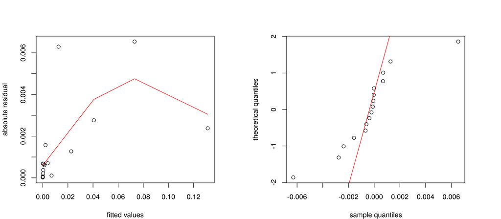

```r
par(mfrow=c(1,2));par(mar=c(4,4,4,4))
plot(fitted(fit_NLS),abs(resid(fit_NLS)),
     xlab="fitted values", ylab="absolute residual")
fit_loess  = loess(abs(resid(fit_NLS))~ fitted(fit_NLS),span=1,deg=1)
ord_NLS = order(fitted(fit_NLS))
lines(fitted(fit_NLS)[ord_NLS],fit_loess$fit[ord_NLS], col="red")
qqnorm(resid(fit_NLS),datax=T,main="",ylab="sample quantiles",
       xlab="theoretical quantiles")
qqline(resid(fit_NLS),datax=T, col="red")
```

- To remedy these issues, we consider the TBS regression obtained by taking the square root of both sides

\begin{align*} \sqrt{Y_n} = e^{0.5\,\beta_0 + 0.5\, \beta_1 X_n} + \epst_n;~~~~~~~~~\eps_n\overset{i.i.d.}{\sim} N(0,1) \end{align*}

```r
fit_TBS = nls(sqrt(freq) ~ exp(b1/2+b2*rating/2), start=list(b1=-6,b2=.5))
summary(fit_TBS)
```

```
Formula: sqrt(freq) ~ exp(b1/2 + b2 * rating/2)

Parameters:
    Estimate Std. Error t value Pr(>|t|)
b1 -12.37289    0.51820  -23.88 9.62e-13 ***
b2   0.64917    0.03459   18.77 2.54e-11 ***
---
Signif. codes:  0 ‘***’ 0.001 ‘**’ 0.01 ‘*’ 0.05 ‘.’ 0.1 ‘ ’ 1

Residual standard error: 0.01401 on 14 degrees of freedom

Number of iterations to convergence: 7
Achieved convergence tolerance: 8.544e-06
```

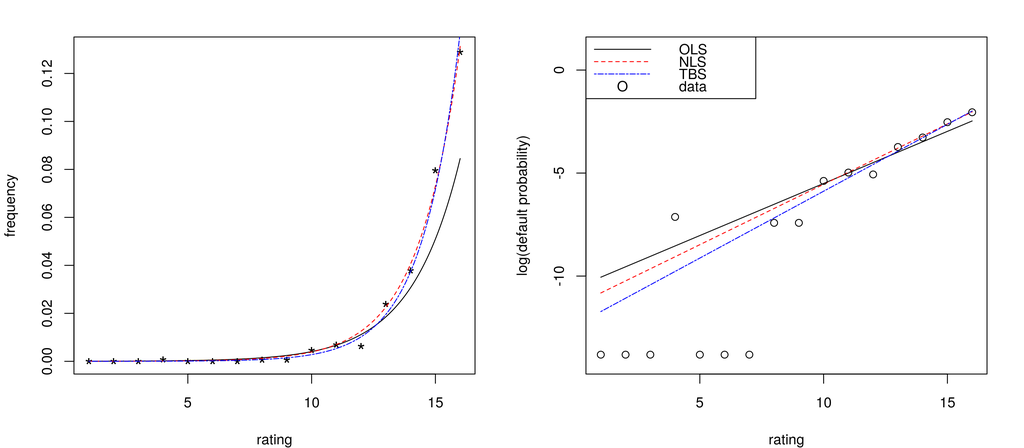

```r
par(mfrow=c(1,2));par(mar=c(4,4,2,2))
coef_TBS = as.numeric(coef(fit_TBS))
logY_grid_TBS = coef_TBS[1]+coef_TBS[2]*rate_grid
plot(rating,freq,ylim=c(-.0001,.13),pch="*",ylab="frequency",cex=1.5)
lines(rate_grid,exp(logY_grid_OLS))
lines(rate_grid,exp(logY_grid_NLS),lty=2,col="red")
lines(rate_grid,exp(logY_grid_TBS),lty=6,col="blue")
plot(rate_grid, logY_grid_OLS,
     type="l",ylim=c(-14.15,1),xlab="rating",ylab="log(default probability)")
lines(rate_grid,logY_grid_NLS,lty=2,col="red")
lines(rate_grid,logY_grid_TBS,lty=6,col="blue")
points(rating,log(freq+1e-6)) # we added 1e-6 so the zero frequencies become visible
legend("topleft",c("OLS","NLS", "TBS","data"),
       lty=c(1,2,6,NA),pch=c("","","","O"),col=c("black","red","blue"))
```

- According to the residual diagnostic, the residual of TBS are normal and have constant variance.

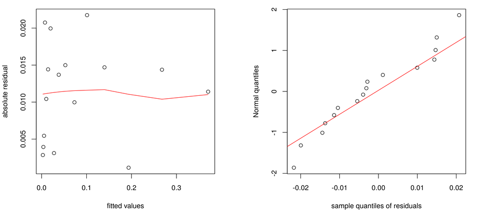

```r
par(mfrow=c(1,2));par(mar=c(5,4,1,4))
plot(fitted(fit_TBS),abs(resid(fit_TBS)),xlab="fitted values",
     ylab="absolute residual")
fit_loess  = loess(abs(resid(fit_TBS))~ fitted(fit_TBS),span=1,deg=1)
ord_tbs = order(fitted(fit_TBS))
lines(fitted(fit_TBS)[ord_tbs],fit_loess$fit[ord_tbs], col="red")
qqnorm(resid(fit_TBS),datax=T,main="",ylab="sample quantiles of residuals",
       xlab="Normal quantiles")
qqline(resid(fit_TBS),datax=T, col="red")
```

- How does TBS works? How do we find the "correct" transformation function?
- TBS regression works by assigning weights to observations in the sum of squares errors
- To see this, consider Taylor's expansion of the NLS objective function for a TBS regression

\begin{align*} \sum_{n=1}^N \left[h(Y_n) - h\left(f(\Xv_n;\betav)\right)\right]^2 &\approx \sum_{n=1}^N \left[h'\left(f(\Xv_n;\betav)\right)\left(Y_n-f(\Xv_n;\betav)\right)\right]^2\\ &= \sum_{n=1}^N \left[h'\left(f(\Xv_n;\betav)\right)\right]^2\left[Y_n-f(\Xv_n;\betav)\right]^2 \end{align*}

- The NLS objective function for the original model is $\sum_{n=1}^N \left[Y_n-f(\Xv_n;\betav)\right]^2$
- Therefore, TBS regression effectively assigns weights to observations, the weight for the n-th observation is $\left[h'\left(f(\Xv_n;\betav)\right)\right]^2$
- One of the main use of TBS regression is to restore constant variance of residuals
- To this end, the weights in TBS should be inversely proportional to the conditional variance of response given predictors

\begin{align}\tag{$\star$} \left[h'\left(f(\Xv_n;\betav)\right)\right]^2\propto \frac{1}{\Var(Y_n|\Xv_n)} \end{align}

- This relationship can be used to identify an appropriate $h$ in the TBS regression
- Let us see how to find the **"variance stabilizing transformation"** in the default rate example
- The default rate $Y_n$ in the previous example can be seen as the number of defaults (per each credit score category) divided by a fixed number (i.e. the total number of companies in that category)
- Can you suggest a distribution for $Y_n|\Xv_n$?
- We can choose Poisson or binomial distribution. Calculations are simpler with Poisson.
- We assume that $Y_n|\Xv_n$ is Poisson with conditional mean (and variance) of $f(\Xv_n;\betav)$
- To find a function h that *stabilizes* the variance of errors, we may use equation $(\star)$

\begin{align*} \left[h'\left(f(\Xv_n;\betav)\right)\right]^2\propto \frac{1}{\Var(Y_n|\Xv_n)} = \frac{1}{f(\Xv_n;\betav)} \end{align*}

- Therefore, $h$ must satisfy $h'(x) = \frac{k}{\sqrt{x}}$, for some constant $k\ne0$
- By integrating both sides, we obtain $h(x) = 2\,k \sqrt{x} + C$, where $k$ and $C$ are arbitrary constants and $(\star)$ holds for any choice of their values
- For example, we may choose $k=1/2$ and $C=0$ to obtain $h(x)=\sqrt{x}$
- This yields the TBS regression that we fitted above
- Note that to find the variance stabilizing TBS regression, we had to make assumption on the distribution of the response, that is, we assumed it is Poisson
- In general, to find the variance stabilizing TBS regression, we needed to make distributional assumptions
- The next transformation takes a more "agnostic" approach.

## 2.2. Box-Cox transformation

- This transformation is also used for correcting abnormalities in regression diagnostic, such as non-normality or non-constant variance of residuals
- Only the response variable is transformed

\begin{align*} Y_n^\al = \beta_0 + \beta_1\, X_{n,1} + \dots + \beta_p\,X_{n,p} + \eps_n;\quad n\in\{1,\dots,N\} \end{align*}

- Here, $\al$, $\beta_0$, ..., $\beta_p$ are unknown parameters to be estimated
- The parameters are estimated by the **profile MLE** method, which we explain next (profile MLE is discussed in section 5.15 of the textbook)
- Let $L(\al, \betav)$ be the likelihood function in MLE for the parameters. Then,

\begin{align*} L(\alh_\text{ML},\betavh_\text{ML}) = \underset{\al,\betav}{\max} L(\al, \betav) = \underset{\al}{\max}\Big\{\underset{\betav}{\max} L(\al, \betav)\Big\} \end{align*}

- Let us define

\begin{align*} L_{\max}(\al)=\underset{\betav}{\max} L(\al, \betav) \end{align*}

- We then have

\begin{align*} \alh_\text{ML} := \underset{\al}{\arg\max}\,L_{\max}(\al), \end{align*}

- This motivates the following two-step approach
- **Step 1:** Draw the function $L_\max(\al)$ and choose its maximizer. Usually, a **"round value"** near the maximizer of $L_\max(\al)$ is chosen. Let us denote it by $\alh$
- **Step2:** We obtain the estimator $\betavh$ by fitting the following multiple linear regression model (using OLS):

\begin{align*} Y_n^{\alh} = \beta_0 + \beta_1\, X_{n,1} + \dots + \beta_p\,X_{n,p} + \eps_n;\quad n\in\{1,\dots,N\} \end{align*}

- Note that Box-Cox transformation is designed for multiple **linear** regression, so, we cannot apply it to remedy the non-constant variance of model 2 in the default example
- Let us illustrate Box-Cox transformation by a new example using simulated data

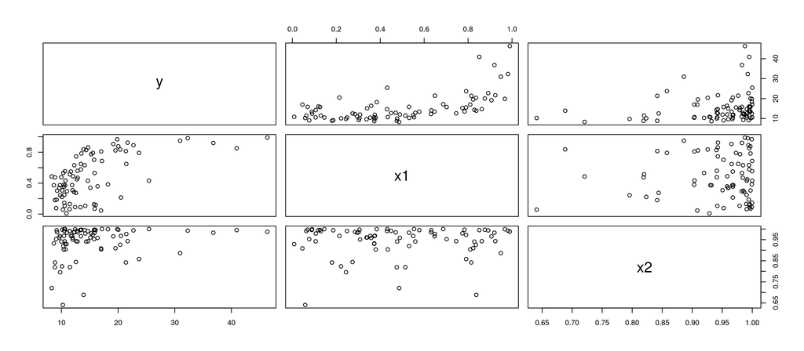

```r
n = 80
set.seed("781235")
e = matrix(runif(12*n),nrow=n) %*% rep(1,12)
e = abs(e)^4
e= e/mean(e)
x1 = runif(n)
x1 = sort(x1)
x2 = rbeta(n,6,.5)
y = (8*x2 + x1 + 5*x1^3) + ( 4* x2 + x1 + 7*x1^3) * e
pairs(~y+x1+x2)
```

- We consider fitting a polynomial regression

\begin{align*} Y_n = \beta_0 + \beta_1 X_{n,1} + \beta_2 X_{n,1}^2 + \beta_3 X_{n,2} + \eps_n \end{align*}

```r
fit_linear = lm(y ~ x1 + I(x1^2) + x2) # we need to use I(x1^2) instead of x1^2
summary(fit_linear)
```

```
Call:
lm(formula = y ~ x1 + I(x1^2) + x2)

Residuals:
    Min      1Q  Median      3Q     Max
-9.0508 -2.3753 -0.8955  1.4037 17.7113

Coefficients:
            Estimate Std. Error t value Pr(>|t|)
(Intercept)   -1.273      7.190  -0.177 0.859881
x1           -27.311      7.695  -3.549 0.000666 ***
I(x1^2)       41.620      7.394   5.629  2.9e-07 ***
x2            17.666      7.433   2.377 0.019979 *
---
Signif. codes:  0 ‘***’ 0.001 ‘**’ 0.01 ‘*’ 0.05 ‘.’ 0.1 ‘ ’ 1

Residual standard error: 4.784 on 76 degrees of freedom
Multiple R-squared:  0.5667,	Adjusted R-squared:  0.5496
F-statistic: 33.13 on 3 and 76 DF,  p-value: 8.423e-14
```

- Residual analysis indicates non-constant variance and non-normality

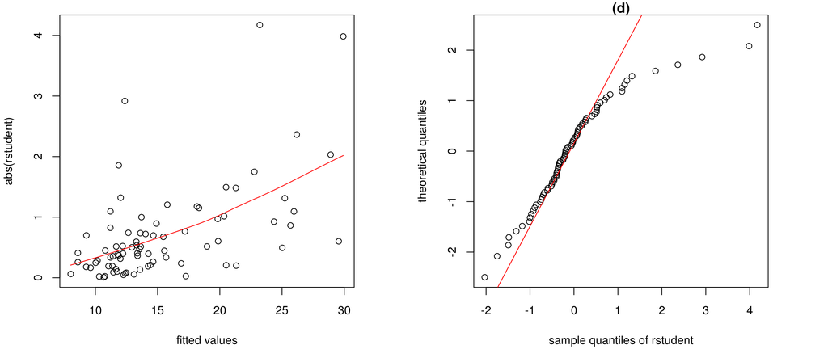

```r
par(mfrow=c(1,2));par(mar=c(5,4,1,4))
plot(fit_linear$fitted,abs(rstudent(fit_linear)),xlab = "fitted values", ylab = "abs(rstudent)")
fit_loess  = loess(abs(rstudent(fit_linear))~ fit_linear$fitted,span=1,deg=1)
ord = order(fit_linear$fitted)
lines(fit_linear$fitted[ord],fit_loess$fit[ord], col="red")
qqnorm(rstudent(fit_linear),datax=T,main="(d)",xlab="theoretical quantiles",ylab="sample quantiles of rstudent")
qqline(rstudent(fit_linear),datax=T, col="red")
```

- Next, we correct the abnormalities by Box-Cox transformation
- To obtain $\alh$ in the first step of profile MLE, we can use `boxcox()` function in `MASS` package
- The default domain is $[-2,2]$. If the maximum is not attained, use the argument `lambda = seq(a, b, 1/10)` to change the domain to $[a,b]$

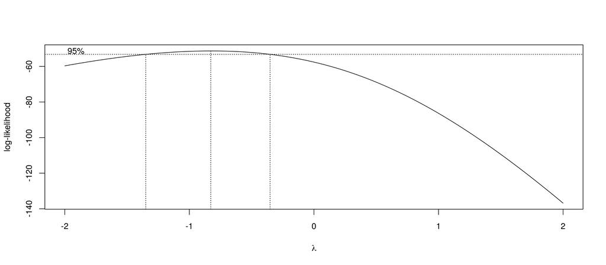

```r
library(MASS)
L_max = boxcox(y ~ x1 + I(x1^2) + x2,ylab="log-likelihood")
```

- We can obtain the exact value of the maximizer of $L_\max(\al)$ as follows. It is acceptable to use the nearest round value, say $-1$

```r
alphahat = L_max$x[which.max(L_max$y)]
alphahat
```

-0.828282828282828

- Next, we find the estimates for $\beta_0$, $\beta_1$, $\beta_2$, and $\beta_3$ by fitting the transformed model $Y_n^\alh = \beta_0 + \beta_1 X_{n,1} + \beta_2 X_{n,1}^2 + \beta_3 X_{n,2} + \eps_n$

```r
y2 = y^alphahat
fit_BoxCox = lm(y2 ~ x1 + I(x1^2) + x2)
summary(fit_BoxCox)
```

```
Call:
lm(formula = y2 ~ x1 + I(x1^2) + x2)

Residuals:
      Min        1Q    Median        3Q       Max
-0.057254 -0.011468  0.001647  0.014278  0.035730

Coefficients:
            Estimate Std. Error t value Pr(>|t|)
(Intercept)  0.22050    0.03016   7.310 2.28e-10 ***
x1           0.09853    0.03228   3.052 0.003133 **
I(x1^2)     -0.16256    0.03102  -5.240 1.39e-06 ***
x2          -0.10697    0.03118  -3.430 0.000978 ***
---
Signif. codes:  0 ‘***’ 0.001 ‘**’ 0.01 ‘*’ 0.05 ‘.’ 0.1 ‘ ’ 1

Residual standard error: 0.02007 on 76 degrees of freedom
Multiple R-squared:  0.5909,	Adjusted R-squared:  0.5747
F-statistic: 36.59 on 3 and 76 DF,  p-value: 9.69e-15
```

- Thus, we obtain the following fitted model \begin{align*} Y_n^{-0.83} = 0.22 + 0.0985 X_{n,1} - 0.163 X_{n,1}^2 - 0.107 X_{n,2} + \eps_n \end{align*}
- The residual analysis shows that the issues are corrected

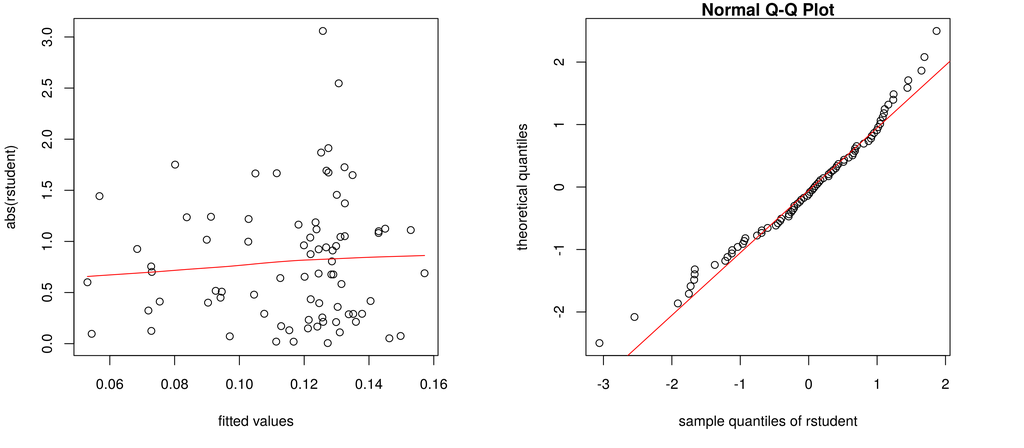

```r
resid = rstudent(fit_BoxCox); yhat = fitted(fit_BoxCox)
par(mfrow=c(1,2));par(mar=c(5,4,1,4))
plot(yhat,abs(resid),xlab = "fitted values", ylab = "abs(rstudent)")
fit_loess  = loess(abs(resid)~ yhat,span=1,deg=1)
ord = order(yhat)
lines(yhat[ord],fit_loess$fit[ord], col="red")
qqnorm(resid,datax=T,xlab="theoretical quantiles",ylab="sample quantiles of rstudent")
qqline(resid,datax=T, col="red")
```

# 3. Logit regression

- **Classification** can be seen as a regression problem where the response variable is discrete and takes finite number of values, say $\{0, 1, 2,\dots,K-1\}$
- Example: spam filter; classifying news as good, bad, or neutral; classifying faces as male or female
- In machine learning literature, regression and classification are seen as two different tasks. Regression is about predicting values while the goal of classification is to predict categories
- Here, we only consider **binary classification**, where there are only two categories (i.e. $K=2$), which we label as 0 and 1
- We discuss a parametric regression model for the binary classification problem
- Classification problems are more thoroughly discussed in CFRM 521
- Consider the regression model $Y_n = f(\Xv_n;\betav)+\eps_n$, where $Y_n\in\{0,1\}$
- Can we fit this model using NLS (or OLS if $f(\Xv_n;\betav)$ is linear in $\betav$)?
- The answer is negative.
- We have

\begin{align*} f(\Xv_n;\betav) = \Eb(Y_n|\Xv_n) = \Pb(Y_n=1|\Xv_n) \end{align*}

- Therefore

\begin{align*} 0\le f(\Xv_n;\betav)\le1 \end{align*}

- We need to take this constraint into account
- This can be done using generalized linear models (GLM), which we discuss next
- In GLM, we consider the parametric non-linear model

\begin{align*} Y_n = H(\beta_0 + \beta_1\,X_{n,1} + \dots + \beta_p\,X_{n,p}) + \eps_n \end{align*}

- For binary classification, $H(x)$ is a CDF function (i.e. a non-decreasing function that satisfies $\lim_{x\to-\infty}H(x)=0$ and $\lim_{x\to\infty}H(x)=1$)
- Two common choices of $H$ are:
  - **Probit regression:** H is the standard normal CDF given by $\displaystyle H(x) = \int_{-\infty}^x\frac{\ee^{-x^2/2}}{\sqrt{2\pi}}\dd x$
  - **Logit regression:** H is the logistic CDF given by $\displaystyle H(x) = \frac{1}{1+\ee^{-x}}$
- Once $H(x)$ is chosen, the parameters $\beta_0$,..., $\beta_p$ are estimated by Maximum Likelihood Estimation (MLE)
- Note that for the binary response model, $Y_n|\Xv_n$ are i.i.d. Bernoulli random variables with parameter $p=\Pb(Y_n=1|\Xv_n) = f(\Xv_n;\betav)$ (as we have shown before)
- Let us calculate the likelihood function of a sample $Y_1,\dots,Y_N$, if the true values of the regression parameters are $\betav$

\begin{align*} L(\betav) &=\prod_{n=1}^N \Big[\Pb(Y_n=1|\Xv_n)\Big]^{Y_n}\Big[\Pb(Y_n=0|\Xv_n)\Big]^{1-Y_n}\\ &=\prod_{n=1}^N \Big[H(\beta_0 + \beta_1\,X_{n,1} + \dots + \beta_p\,X_{n,p})\Big]^{Y_n}\\ &\qquad\qquad\Big[1-H(\beta_0 + \beta_1\,X_{n,1} + \dots + \beta_p\,X_{n,p})\Big]^{1-Y_n} \end{align*}

- The maximum likelihood estimator (MLE) of the model parameter is

\begin{align*} \betavh_\text{ML} = \underset{\betav}{\arg\max}\, L(\betav) \end{align*}

- To solve this optimization problem, we need to use a numerical method
- Let us fit a binary classification model using R
- We use the dataset `CreditCard` in the R package `AER`, which contains various information about applicants for a certain credit card, along with the outcome of the application (stored in the column `card`)
- See Example 11.7 in Section 11.6 of the textbook for a description of the data
- The following code load the data and remove nonsensical observations (the ones with applicant age less than 18)

```r
library("AER");library("faraway");library("MASS")
data("CreditCard")
```

```r
CreditCard_clean = CreditCard[CreditCard$age>18,]
attach(CreditCard_clean)
```

- Let us take a look at the data

```r
head(CreditCard_clean)
names(CreditCard_clean)
dim(CreditCard_clean)
```

A data.frame: 6 × 12

| card <fct> | reports <dbl> | age <dbl> | income <dbl> | share <dbl> | expenditure <dbl> | owner <fct> | selfemp <fct> | dependents <dbl> | months <dbl> | majorcards <dbl> | active <dbl> |
| --- | --- | --- | --- | --- | --- | --- | --- | --- | --- | --- | --- |
| yes | 0 | 37.66667 | 4.5200 | 0.033269910 | 124.983300 | yes | no | 3 | 54 | 1 | 12 |
| yes | 0 | 33.25000 | 2.4200 | 0.005216942 | 9.854167 | no | no | 3 | 34 | 1 | 13 |
| yes | 0 | 33.66667 | 4.5000 | 0.004155556 | 15.000000 | yes | no | 4 | 58 | 1 | 5 |
| yes | 0 | 30.50000 | 2.5400 | 0.065213780 | 137.869200 | no | no | 0 | 25 | 1 | 7 |
| yes | 0 | 32.16667 | 9.7867 | 0.067050590 | 546.503300 | yes | no | 2 | 64 | 1 | 5 |
| yes | 0 | 23.25000 | 2.5000 | 0.044438400 | 91.996670 | no | no | 0 | 54 | 1 | 1 |

1. 'card'

2. 'reports'

3. 'age'

4. 'income'

5. 'share'

6. 'expenditure'

7. 'owner'

8. 'selfemp'

9. 'dependents'

10. 'months'

11. 'majorcards'

12. 'active'

1. 1312

2. 12

- Based on this data, we would like to come up with a model to accept or reject applications
- We take `card` as the response variable and the application information as the predictors
- This problem can be solved by a binary response regression (since the response variable, `card`, takes only two values `yes` or `no`)
- As can be seen from the histogram of the predictor, some are very skewed, which result in high-leverage points. To correct this, we replace the skewed variables with their logarithm

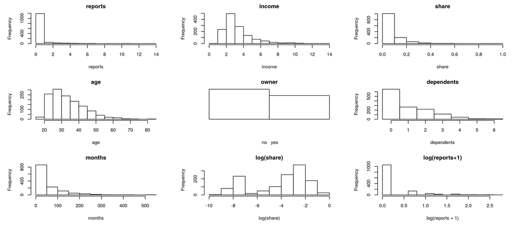

```r
par(mfrow=c(3,3));par(mar=c(5,5,2,2))
hist(reports,main="reports")
hist(income, main="income")
hist(share, main="share")
hist(age, main="age")
hist(as.numeric(owner), main="owner",
     breaks=2,xlab=" no   yes",axes=F,ylab="")
h=hist(dependents,main="dependents",breaks=(0:7)-.5)
hist(months,main="months")
hist(log(share),main="log(share)")
hist(log(reports+1),main="log(reports+1)")
```

- Let us fit a logistic model using all the variables. We can use the R function `glm()` with argument `family= binomial(link = "logit")` to fit a logit model

```r
fit1= glm(card~log(reports+1)+income+log(share)+age+owner+dependents+months,
          family= binomial(link = "logit"), data=CreditCard_clean)
summary(fit1)
```

```
Call:
glm(formula = card ~ log(reports + 1) + income + log(share) +
    age + owner + dependents + months, family = binomial(link = "logit"),
    data = CreditCard_clean)

Deviance Residuals:
     Min        1Q    Median        3Q       Max
-1.63787   0.00004   0.00044   0.00225   2.87105

Coefficients:
                  Estimate Std. Error z value Pr(>|z|)
(Intercept)      21.473930   3.674325   5.844 5.09e-09 ***
log(reports + 1) -2.908644   1.097604  -2.650  0.00805 **
income            0.903315   0.189754   4.760 1.93e-06 ***
log(share)        3.422980   0.530499   6.452 1.10e-10 ***
age               0.022682   0.021895   1.036  0.30024
owneryes          0.705171   0.533070   1.323  0.18589
dependents       -0.664933   0.267404  -2.487  0.01290 *
months           -0.005723   0.003988  -1.435  0.15130
---
Signif. codes:  0 ‘***’ 0.001 ‘**’ 0.01 ‘*’ 0.05 ‘.’ 0.1 ‘ ’ 1

(Dispersion parameter for binomial family taken to be 1)

    Null deviance: 1398.53  on 1311  degrees of freedom
Residual deviance:  139.79  on 1304  degrees of freedom
AIC: 155.79

Number of Fisher Scoring iterations: 11
```

- As can be seen, some variables are insignificant, we can remove these variables and fit the model again
- A more systematic way is to conduct a variable selection using the `stepAIC()` function of `MASS` package. This function has a similar goal as the `regsubsets()` function that we used in lecture 3.
- The output is long, the final selection of `stepAIC` are the following predictors: `dependents`, `log(reports + 1)`, `income`, and `log(share)`

```r
stepAIC(fit1)
```

```
Start:  AIC=155.79
card ~ log(reports + 1) + income + log(share) + age + owner +
    dependents + months
```

```
                   Df Deviance     AIC
- age               1   140.85  154.85
- owner             1   141.49  155.49
<none>                  139.79  155.79
- months            1   142.21  156.21
- dependents        1   147.86  161.86
- log(reports + 1)  1   159.50  173.50
- income            1   166.42  180.42
- log(share)        1  1057.26 1071.26

Step:  AIC=154.85
card ~ log(reports + 1) + income + log(share) + owner + dependents +
    months
```

```
                   Df Deviance     AIC
- months            1   142.39  154.39
<none>                  140.85  154.85
- owner             1   143.65  155.65
- dependents        1   148.73  160.73
- log(reports + 1)  1   160.26  172.26
- income            1   168.29  180.29
- log(share)        1  1058.31 1070.31

Step:  AIC=154.39
card ~ log(reports + 1) + income + log(share) + owner + dependents
```

```
                   Df Deviance     AIC
- owner             1   144.22  154.22
<none>                  142.39  154.39
- dependents        1   149.11  159.11
- log(reports + 1)  1   162.26  172.26
- income            1   168.31  178.31
- log(share)        1  1058.33 1068.33

Step:  AIC=154.22
card ~ log(reports + 1) + income + log(share) + dependents

                   Df Deviance     AIC
<none>                  144.22  154.22
- dependents        1   150.28  158.28
- log(reports + 1)  1   164.18  172.18
- income            1   173.62  181.62
- log(share)        1  1079.61 1087.61
```

```
Call:  glm(formula = card ~ log(reports + 1) + income + log(share) +
    dependents, family = binomial(link = "logit"), data = CreditCard_clean)

Coefficients:
     (Intercept)  log(reports + 1)            income        log(share)
         21.3224           -2.8953            0.8717            3.3102
      dependents
         -0.5506

Degrees of Freedom: 1311 Total (i.e. Null);  1307 Residual
Null Deviance:	    1399
Residual Deviance: 144.2 	AIC: 154.2
```

- Next, we fit the parsimonious model. We also "center" the predictors to simplify interpretation of the model

```r
log_reports_c = log(reports+1)
log_reports_c = log_reports_c - mean(log_reports_c)
income_c = income - mean(income)
log_share_c = log(share) - mean(log(share))
dependents_c = dependents - mean(dependents)

# fitting a parsimonious logit model
glm_fit02 = glm(card~log_reports_c+income_c+log_share_c+dependents_c,
                family= binomial(link = "logit"),data=CreditCard_clean)
summary(glm_fit02)
```

```
Call:
glm(formula = card ~ log_reports_c + income_c + log_share_c +
    dependents_c, family = binomial(link = "logit"), data = CreditCard_clean)

Deviance Residuals:
     Min        1Q    Median        3Q       Max
-1.50664   0.00006   0.00061   0.00280   2.79345

Coefficients:
              Estimate Std. Error z value Pr(>|z|)
(Intercept)     9.5238     1.7213   5.533 3.15e-08 ***
log_reports_c  -2.8953     1.0866  -2.664  0.00771 **
income_c        0.8717     0.1724   5.056 4.28e-07 ***
log_share_c     3.3102     0.4942   6.698 2.11e-11 ***
dependents_c   -0.5506     0.2505  -2.198  0.02793 *
---
Signif. codes:  0 ‘***’ 0.001 ‘**’ 0.01 ‘*’ 0.05 ‘.’ 0.1 ‘ ’ 1

(Dispersion parameter for binomial family taken to be 1)

    Null deviance: 1398.53  on 1311  degrees of freedom
Residual deviance:  144.22  on 1307  degrees of freedom
AIC: 154.22

Number of Fisher Scoring iterations: 11
```

- Let us find out which predictor has more effect on the probability of acceptance of an application

```r
income_grid = seq(min(income),max(income),.01)
share_grid = exp(seq(min(log(share)),max(log(share)),.01))
share_grid2 = log(share_grid) - mean(log(share))
reports_grid = 0:14
reports_grid2 = log(reports_grid+1) - mean(log(reports+1))
```

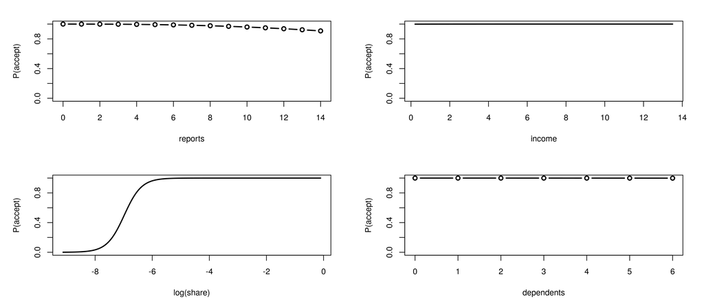

```r
par(mfrow=c(2,2)); par(mar=c(5,5,2,2))
plot(reports_grid, plogis(9.5238 -2.8953 * reports_grid2 ),type="b",
     lwd=2,xlab="reports",ylab="P(accept)",ylim=c(0,1))
plot(income_grid, plogis(9.5238 + 0.8717 *(income_grid-mean(income)) ),type="l",
     cex=2,lwd=2,xlab="income",ylab="P(accept)",ylim=c(0,1))
plot(log(share_grid), plogis(9.5238  + 3.3102  * share_grid2 ),type="l",
     cex=2,lwd=2,xlab="log(share)",ylab="P(accept)",ylim=c(0,1))
plot(0:6,plogis(9.5238 - .5506*((0:6)-mean(dependents)) ),type="b",
     lwd=2,xlab="dependents",ylab="P(accept)",ylim=c(0,1))
```

# 4. Robust regression

- A robust estimator is designed not to be affected by outliers
- There are many robust regression methods. Here, we consider the least-trimmed sum of squares (LTS) estimator
- Consider a regression model $Y_n = f(\Xv_n;\betav) + \eps_n$
- Define the trimmed sum of squares (TSS) as follows. For each value of $\betav$:
  - Let $\eps_n(\betav) = Y_n - f(\Xv_n;\betav)$, for $n\in\{1,\dots, N\}$
  - Order $\eps_n(\betav)^2$, remove 5% of the observations with largest values of $\eps_n(\betav)^2$. Let $I_0(\betav)$ denote the indices of the remaining 95% of the observations
  - Define the TSS$\displaystyle(\betav):= \sum_{n\in I_0(\betav)}\Big(Y_n-f(\Xv_n;\betav)\Big)^2$
- To estimate the parameters, we minimize TSS$(\beta)$
- Next, we illustrate LTS regression using the example we used for regression diagnostic

```r
# simulating samples
set.seed(99)
x = 1:11
x[11] = 50
y=1+x+rnorm(11)
y2 = y
y2[11] = y[11]-45
x2 = x
x2[11] = 5.5
cexx = c(rep(21,10),19)
start = c(1,1,1,1)
```

- The `ltsReg()` function in `robustbase` package can be used for LTS regression

```r
library("robustbase")
summary(ltsReg(y2~x))
```

```
Call:
ltsReg.formula(formula = y2 ~ x)

Residuals (from reweighted LS):
    Min      1Q  Median      3Q     Max
-0.6193 -0.2865  0.0000  0.2375  0.9112

Coefficients:
          Estimate Std. Error t value Pr(>|t|)
Intercept  1.59222    0.34040   4.678  0.00159 **
x          0.87328    0.05486  15.918 2.43e-07 ***
---
Signif. codes:  0 ‘***’ 0.001 ‘**’ 0.01 ‘*’ 0.05 ‘.’ 0.1 ‘ ’ 1

Residual standard error: 0.4983 on 8 degrees of freedom
Multiple R-Squared: 0.9694,	Adjusted R-squared: 0.9656
F-statistic: 253.4 on 1 and 8 DF,  p-value: 2.429e-07
```

```r
summary(lm(y2~x))
```

```
Call:
lm(formula = y2 ~ x)

Residuals:
    Min      1Q  Median      3Q     Max
-3.9601 -1.8536 -0.5919  2.0496  3.4080

Coefficients:
            Estimate Std. Error t value Pr(>|t|)
(Intercept)  6.16028    1.00866   6.107 0.000178 ***
x            0.01375    0.06228   0.221 0.830210
---
Signif. codes:  0 ‘***’ 0.001 ‘**’ 0.01 ‘*’ 0.05 ‘.’ 0.1 ‘ ’ 1

Residual standard error: 2.702 on 9 degrees of freedom
Multiple R-squared:  0.005386,	Adjusted R-squared:  -0.1051
F-statistic: 0.04873 on 1 and 9 DF,  p-value: 0.8302
```

- As you can see, residual outliers have minimal affect on a robust regression

```r
# Setting parameters of the Jupyter notebook
sc = 1
options(repr.plot.width=16*sc,
        repr.plot.height=6*sc,
        repr.plot.pointsize = 20, # Text height in pt
        repr.plot.bg        = 'white',
        repr.plot.antialias = 'gray',
        #nice medium-res DPI
        repr.plot.res       = 300,
        #jpeg quality bumped from default
        repr.plot.quality   = 90,
        #vector font family
        repr.plot.family    = 'serif') # Vector font family. 'sans', 'serif', 'mono' or a specific one
```

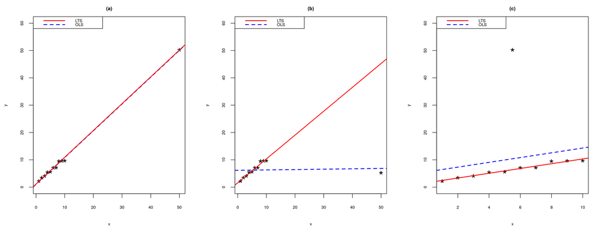

```r
par(mfrow=c(1,3),pch="*");par(mar=c(4,4,2,2))
plot(x,y,ylim=c(0,60),cex=3,main="(a)")
abline(lm(y~x),lty=2,lwd=2,col="blue")
abline(ltsReg(y~x),lwd=2,col="red")
legend("topleft",c("LTS","OLS"),lty=c(1,2),lwd=c(2,2), col=c("red","blue"))
plot(x,y2,ylim=c(0,60),cex=3,ylab="y",main="(b)")
abline(lm(y2~x),lty=2,lwd=2,col="blue")
abline(ltsReg(y2~x),lwd=2,col="red")
legend("topleft",c("LTS","OLS"),lty=c(1,2),lwd=c(2,2), col=c("red","blue"))
plot(x2,y,ylim=c(0,60),cex=3,xlab="x",main="(c)")
abline(lm(y~x2),lwd=2,lty=2,col="blue")
abline(ltsReg(y~x2),lwd=2,col="red")
legend("topleft",c("LTS","OLS"),lty=c(1,2),lwd=c(2,2), col=c("red","blue"))
```